# Manual - Banco local

17 de novembro de 2022

Este manual tem como objetivo conduzir o leitor a reproduzir o banco de dados criado para meu TCC. A maioria dos arquivos estão no [repositório do trabalho](https://github.com/Marcos358/Montagem) no github. Durante o processo de criação enfrentei algumas dificuldades na parte de instalação das dependências que podem variar dependendo do sistema operacional. Os procedimentos aqui descritos foram executados no `Ubuntu 20.04.4 LTS`.

# Ambiente

A coleta dos dados é feita via `pysus`, para instalá-la precisei utilizar o docker. Tentativas semelhantes em ambiente windows falharam. O repositório da [pysus](https://github.com/AlertaDengue/PySUS) contém detalhes para a instalação.

## Postgres

- Instale o [postgres](https://www.postgresql.org/download/) na sua máquina;
- Instale uma IDE para operar o banco. Uma muito utilizada é a [pgAdmin](https://www.pgadmin.org/download/) disponível para vários sistemas operacionais;
- Registre seu usuário e crie um servidor

[figure not shown]

Server Group

- Crie um database e dentro dele um schema: **brasil**. Vou usar o databse **tcc**

[figure not shown]

Schemas

Um motivo para usar o **pgAdmin** é a boa documentação facilitando a resolução de eventuais problemas. Uma maneira mais radical de usar o postgres é sem IDE via linha de comando (`psql <nome do database>`).

Até aqui temos: Um usuário, um host (geralmente **localhost**), um servidor, um database (**tcc**) e um schema: **brasil**.

## Python

O ETL é feito em `python`, portanto no mínimo é preciso ter o python instalado. Os arquivos poderão ser executados pelo terminal, portanto IDEs são dispensáveis. Tem arquivos em jupyter notebook disponíveis também.  
Antes de executar os scripts certifique-se de que tenha as seguintes bibliotcas instaladas:

- `os`
- `time`
- `numpy`
- `pysus`
- `pandas`
- `unicode`
- `datatime`
- `pyspark.sql`
- `IPython.display`
- `psycopg2`

esta última para criar a conexão python <–> postgres.

# Execução

1. Clone o [repositório](https://github.com/Marcos358/Montagem);
2. Coloque a senha do seu usuário do servidor postgres no arquivo ‘senha.txt’;
3. Na linha de comando, execute o arquivo ‘aquisicao.py’ e coloque a janela de tempo. Se quiser dados para apenas um estado específico escreva a sigla quando o programa solicitar, caso contrário, apenas dê Enter

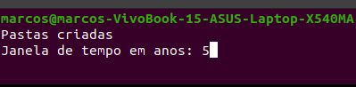

Exec aquisicao.py

**Atenção**: Este processo demora, quanto maior a janela de tempo mais demorada será a execução

4. Na linha de comando, execute o arquivo ‘carga.py’. Serão solicitadas as credenciais do banco de dados, insira-as no terminal

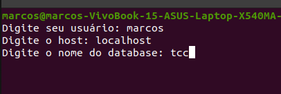

Exec carga.py

O terminal irá informar o progresso no console. Após finazlido o programa os dados estarão disponíveis no banco com a extensão temporal indicada na janela temporal.